# Optimal Treatment Analysis

## Outcome Variable

**Outcome Variable:** haz

## Predictor Variables

**Intervention Variable:** exclfeed6

**Adjustment Set:**

- arm
- sex
- brthmon
- W_mage
- meducyrs
- feducyrs
- hhwealth_quart
- hfoodsec
- W_mhtcm
- W_mwtkg
- W_mbmi
- vagbrth
- W_gagebrth
- W_birthwt
- W_birthlen
- W_nrooms
- W_nchldlt5
- month
- W_parity
- impfloor
- impsan
- safeh20
- delta_W_mage
- delta_meducyrs
- delta_feducyrs
- delta_hhwealth_quart
- delta_hfoodsec
- delta_W_mhtcm
- delta_W_mwtkg
- delta_W_mbmi
- delta_vagbrth
- delta_W_gagebrth
- delta_W_birthwt
- delta_W_birthlen
- delta_W_nrooms
- delta_W_nchldlt5
- delta_month
- delta_W_parity
- delta_impfloor
- delta_impsan
- delta_safeh20

## Stratifying Variables

The analysis was stratified on these variable(s):

- agecat
- studyid
- country

## Data Summary

| agecat | studyid | country | exclfeed6 | n_cell | n |
| --- | --- | --- | --- | --- | --- |
| Birth | CMC-V-BCS-2002 | INDIA | 1 | 7 | 7 |
| Birth | CMC-V-BCS-2002 | INDIA | 0 | 0 | 7 |
| Birth | EE | PAKISTAN | 1 | 38 | 42 |
| Birth | EE | PAKISTAN | 0 | 4 | 42 |
| Birth | GMS-Nepal | NEPAL | 1 | 419 | 563 |
| Birth | GMS-Nepal | NEPAL | 0 | 144 | 563 |
| Birth | IRC | INDIA | 1 | 0 | 14 |
| Birth | IRC | INDIA | 0 | 14 | 14 |
| Birth | JiVitA-3 | BANGLADESH | 1 | 10452 | 13423 |
| Birth | JiVitA-3 | BANGLADESH | 0 | 2971 | 13423 |
| Birth | JiVitA-4 | BANGLADESH | 1 | 2098 | 2632 |
| Birth | JiVitA-4 | BANGLADESH | 0 | 534 | 2632 |
| Birth | Keneba | GAMBIA | 1 | 485 | 1403 |
| Birth | Keneba | GAMBIA | 0 | 918 | 1403 |
| Birth | MAL-ED | BANGLADESH | 1 | 31 | 205 |
| Birth | MAL-ED | BANGLADESH | 0 | 174 | 205 |
| Birth | MAL-ED | BRAZIL | 1 | 2 | 60 |
| Birth | MAL-ED | BRAZIL | 0 | 58 | 60 |
| Birth | MAL-ED | INDIA | 1 | 1 | 39 |
| Birth | MAL-ED | INDIA | 0 | 38 | 39 |
| Birth | MAL-ED | NEPAL | 1 | 2 | 24 |
| Birth | MAL-ED | NEPAL | 0 | 22 | 24 |
| Birth | MAL-ED | PERU | 1 | 2 | 213 |
| Birth | MAL-ED | PERU | 0 | 211 | 213 |
| Birth | MAL-ED | SOUTH AFRICA | 1 | 0 | 91 |
| Birth | MAL-ED | SOUTH AFRICA | 0 | 91 | 91 |
| Birth | MAL-ED | TANZANIA, UNITED REPUBLIC OF | 1 | 0 | 113 |
| Birth | MAL-ED | TANZANIA, UNITED REPUBLIC OF | 0 | 113 | 113 |
| Birth | PROVIDE | BANGLADESH | 1 | 159 | 539 |
| Birth | PROVIDE | BANGLADESH | 0 | 380 | 539 |

[output cut: 70 more lines]

The following strata were considered:

- agecat: 24 months, studyid: CMC-V-BCS-2002, country: INDIA
- agecat: 24 months, studyid: EE, country: PAKISTAN
- agecat: 24 months, studyid: GMS-Nepal, country: NEPAL
- agecat: 24 months, studyid: IRC, country: INDIA
- agecat: 24 months, studyid: JiVitA-3, country: BANGLADESH
- agecat: 24 months, studyid: JiVitA-4, country: BANGLADESH
- agecat: 24 months, studyid: Keneba, country: GAMBIA
- agecat: 24 months, studyid: LCNI-5, country: MALAWI
- agecat: 24 months, studyid: MAL-ED, country: BANGLADESH
- agecat: 24 months, studyid: MAL-ED, country: BRAZIL
- agecat: 24 months, studyid: MAL-ED, country: INDIA
- agecat: 24 months, studyid: MAL-ED, country: NEPAL
- agecat: 24 months, studyid: MAL-ED, country: PERU
- agecat: 24 months, studyid: MAL-ED, country: SOUTH AFRICA
- agecat: 24 months, studyid: MAL-ED, country: TANZANIA, UNITED REPUBLIC OF
- agecat: 24 months, studyid: PROVIDE, country: BANGLADESH
- agecat: 6 months, studyid: CMC-V-BCS-2002, country: INDIA
- agecat: 6 months, studyid: EE, country: PAKISTAN
- agecat: 6 months, studyid: GMS-Nepal, country: NEPAL
- agecat: 6 months, studyid: IRC, country: INDIA
- agecat: 6 months, studyid: JiVitA-3, country: BANGLADESH
- agecat: 6 months, studyid: JiVitA-4, country: BANGLADESH
- agecat: 6 months, studyid: Keneba, country: GAMBIA
- agecat: 6 months, studyid: LCNI-5, country: MALAWI
- agecat: 6 months, studyid: MAL-ED, country: BANGLADESH
- agecat: 6 months, studyid: MAL-ED, country: BRAZIL
- agecat: 6 months, studyid: MAL-ED, country: INDIA
- agecat: 6 months, studyid: MAL-ED, country: NEPAL
- agecat: 6 months, studyid: MAL-ED, country: PERU
- agecat: 6 months, studyid: MAL-ED, country: SOUTH AFRICA
- agecat: 6 months, studyid: MAL-ED, country: TANZANIA, UNITED REPUBLIC OF
- agecat: 6 months, studyid: PROVIDE, country: BANGLADESH
- agecat: 6 months, studyid: SAS-CompFeed, country: INDIA
- agecat: 6 months, studyid: SAS-FoodSuppl, country: INDIA
- agecat: Birth, studyid: CMC-V-BCS-2002, country: INDIA
- agecat: Birth, studyid: EE, country: PAKISTAN
- agecat: Birth, studyid: GMS-Nepal, country: NEPAL
- agecat: Birth, studyid: IRC, country: INDIA
- agecat: Birth, studyid: JiVitA-3, country: BANGLADESH
- agecat: Birth, studyid: JiVitA-4, country: BANGLADESH
- agecat: Birth, studyid: Keneba, country: GAMBIA
- agecat: Birth, studyid: MAL-ED, country: BANGLADESH
- agecat: Birth, studyid: MAL-ED, country: BRAZIL
- agecat: Birth, studyid: MAL-ED, country: INDIA
- agecat: Birth, studyid: MAL-ED, country: NEPAL
- agecat: Birth, studyid: MAL-ED, country: PERU
- agecat: Birth, studyid: MAL-ED, country: SOUTH AFRICA
- agecat: Birth, studyid: MAL-ED, country: TANZANIA, UNITED REPUBLIC OF
- agecat: Birth, studyid: PROVIDE, country: BANGLADESH
- agecat: Birth, studyid: SAS-CompFeed, country: INDIA

### Dropped Strata

- agecat: Birth, studyid: CMC-V-BCS-2002, country: INDIA
- agecat: Birth, studyid: EE, country: PAKISTAN
- agecat: Birth, studyid: IRC, country: INDIA
- agecat: Birth, studyid: MAL-ED, country: BRAZIL
- agecat: Birth, studyid: MAL-ED, country: INDIA
- agecat: Birth, studyid: MAL-ED, country: NEPAL
- agecat: Birth, studyid: MAL-ED, country: PERU
- agecat: Birth, studyid: MAL-ED, country: SOUTH AFRICA
- agecat: Birth, studyid: MAL-ED, country: TANZANIA, UNITED REPUBLIC OF
- agecat: 6 months, studyid: CMC-V-BCS-2002, country: INDIA
- agecat: 6 months, studyid: IRC, country: INDIA
- agecat: 6 months, studyid: MAL-ED, country: INDIA
- agecat: 6 months, studyid: MAL-ED, country: SOUTH AFRICA
- agecat: 6 months, studyid: MAL-ED, country: TANZANIA, UNITED REPUBLIC OF
- agecat: 6 months, studyid: SAS-FoodSuppl, country: INDIA
- agecat: 24 months, studyid: CMC-V-BCS-2002, country: INDIA
- agecat: 24 months, studyid: EE, country: PAKISTAN
- agecat: 24 months, studyid: IRC, country: INDIA
- agecat: 24 months, studyid: MAL-ED, country: INDIA
- agecat: 24 months, studyid: MAL-ED, country: PERU
- agecat: 24 months, studyid: MAL-ED, country: SOUTH AFRICA
- agecat: 24 months, studyid: MAL-ED, country: TANZANIA, UNITED REPUBLIC OF

## Methods Detail

We’re interested in the causal parameters $E[Y_a]$ for all values of $a \in \mathcal{A}$. These parameters represent the mean outcome if, possibly contrary to fact, we intervened to set all units to have $A=a$. Under the randomization and positivity assumptions, these are identified by the statistical parameters $\psi_a=E_W[E_{Y|A,W}(Y|A=a,W)]$. In addition, we’re interested in the mean of $Y$, $E[Y]$ under no intervention (the observed mean). We will estimate these parameters by using SuperLearner to fit the relevant likelihood factors – $E_{Y|A,W}(Y|A=a,W)$ and $p(A=a|W)$, and then updating our likelihood fit using a joint TMLE.

For unadjusted analyses ($W=\{\}$), initial likelihoods were estimated using Lrnr_glm to estimate the simple $E(Y|A)$ and Lrnr_mean to estimate $p(A)$. For adjusted analyses, a small library containing Lrnr_glmnet, Lrnr_xgboost, and Lrnr_mean was used.

Having estimated these parameters, we will then use the delta method to estimate relative risks and attributable risks relative to a prespecified baseline level of $A$.

# Results Detail

## Results Plots

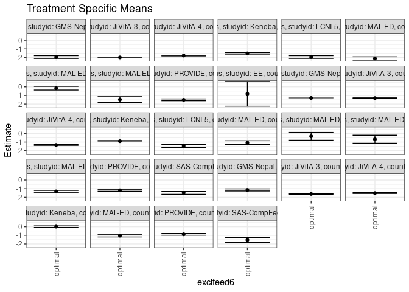

## Results Table

### Parameter: TSM

| agecat | studyid | country | intervention_level | baseline_level | estimate | ci_lower | ci_upper |
| --- | --- | --- | --- | --- | --- | --- | --- |
| Birth | GMS-Nepal | NEPAL | optimal | observed | -1.1449716 | -1.2655704 | -1.0243729 |
| Birth | JiVitA-3 | BANGLADESH | optimal | observed | -1.6113015 | -1.6410324 | -1.5815707 |
| Birth | JiVitA-4 | BANGLADESH | optimal | observed | -1.5078448 | -1.5606159 | -1.4550737 |
| Birth | Keneba | GAMBIA | optimal | observed | 0.0127196 | -0.0765719 | 0.1020111 |
| Birth | MAL-ED | BANGLADESH | optimal | observed | -1.0363681 | -1.1894973 | -0.8832390 |
| Birth | PROVIDE | BANGLADESH | optimal | observed | -0.8835169 | -0.9867325 | -0.7803013 |
| Birth | SAS-CompFeed | INDIA | optimal | observed | -1.5394402 | -1.8299178 | -1.2489627 |
| 6 months | EE | PAKISTAN | optimal | observed | -0.8166759 | -2.2488773 | 0.6155256 |
| 6 months | GMS-Nepal | NEPAL | optimal | observed | -1.2910129 | -1.3783098 | -1.2037160 |
| 6 months | JiVitA-3 | BANGLADESH | optimal | observed | -1.3073357 | -1.3377301 | -1.2769412 |
| 6 months | JiVitA-4 | BANGLADESH | optimal | observed | -1.3372695 | -1.3882726 | -1.2862664 |
| 6 months | Keneba | GAMBIA | optimal | observed | -0.8979088 | -0.9722996 | -0.8235179 |
| 6 months | LCNI-5 | MALAWI | optimal | observed | -1.4518775 | -1.6319101 | -1.2718448 |
| 6 months | MAL-ED | BANGLADESH | optimal | observed | -1.0668085 | -1.2882565 | -0.8453604 |
| 6 months | MAL-ED | BRAZIL | optimal | observed | -0.3314743 | -0.7859954 | 0.1230468 |
| 6 months | MAL-ED | NEPAL | optimal | observed | -0.6721787 | -1.1402625 | -0.2040949 |
| 6 months | MAL-ED | PERU | optimal | observed | -1.3118158 | -1.4225160 | -1.2011157 |
| 6 months | PROVIDE | BANGLADESH | optimal | observed | -1.1850195 | -1.3011806 | -1.0688584 |
| 6 months | SAS-CompFeed | INDIA | optimal | observed | -1.4877061 | -1.6531098 | -1.3223023 |
| 24 months | GMS-Nepal | NEPAL | optimal | observed | -1.9526471 | -2.1137722 | -1.7915220 |
| 24 months | JiVitA-3 | BANGLADESH | optimal | observed | -1.9966255 | -2.0427752 | -1.9504757 |
| 24 months | JiVitA-4 | BANGLADESH | optimal | observed | -1.7799705 | -1.8217708 | -1.7381701 |
| 24 months | Keneba | GAMBIA | optimal | observed | -1.5257814 | -1.6118495 | -1.4397132 |
| 24 months | LCNI-5 | MALAWI | optimal | observed | -1.9501123 | -2.1095618 | -1.7906628 |
| 24 months | MAL-ED | BANGLADESH | optimal | observed | -2.1169904 | -2.3110618 | -1.9229190 |
| 24 months | MAL-ED | BRAZIL | optimal | observed | -0.1599880 | -0.3727011 | 0.0527250 |
| 24 months | MAL-ED | NEPAL | optimal | observed | -1.4756854 | -1.8106062 | -1.1407647 |
| 24 months | PROVIDE | BANGLADESH | optimal | observed | -1.5081889 | -1.6162376 | -1.4001403 |

### Parameter: E(Y)

| agecat | studyid | country | intervention_level | baseline_level | estimate | ci_lower | ci_upper |
| --- | --- | --- | --- | --- | --- | --- | --- |
| Birth | GMS-Nepal | NEPAL | observed | observed | -1.0641208 | -1.1525364 | -0.9757052 |
| Birth | JiVitA-3 | BANGLADESH | observed | observed | -1.5955338 | -1.6186322 | -1.5724354 |
| Birth | JiVitA-4 | BANGLADESH | observed | observed | -1.5273138 | -1.5765339 | -1.4780937 |
| Birth | Keneba | GAMBIA | observed | observed | 0.0126443 | -0.0554367 | 0.0807254 |
| Birth | MAL-ED | BANGLADESH | observed | observed | -1.0530244 | -1.1913751 | -0.9146736 |
| Birth | PROVIDE | BANGLADESH | observed | observed | -0.8851020 | -0.9601332 | -0.8100709 |
| Birth | SAS-CompFeed | INDIA | observed | observed | -1.3937088 | -1.5095039 | -1.2779137 |
| 6 months | EE | PAKISTAN | observed | observed | -2.1595486 | -2.5331781 | -1.7859192 |
| 6 months | GMS-Nepal | NEPAL | observed | observed | -1.3540280 | -1.4334801 | -1.2745760 |
| 6 months | JiVitA-3 | BANGLADESH | observed | observed | -1.3138259 | -1.3418712 | -1.2857806 |
| 6 months | JiVitA-4 | BANGLADESH | observed | observed | -1.3482303 | -1.3866421 | -1.3098185 |
| 6 months | Keneba | GAMBIA | observed | observed | -0.9331108 | -0.9823173 | -0.8839043 |
| 6 months | LCNI-5 | MALAWI | observed | observed | -1.6395956 | -1.7592633 | -1.5199278 |
| 6 months | MAL-ED | BANGLADESH | observed | observed | -1.1900794 | -1.3096296 | -1.0705291 |
| 6 months | MAL-ED | BRAZIL | observed | observed | 0.0475758 | -0.0963508 | 0.1915023 |
| 6 months | MAL-ED | NEPAL | observed | observed | -0.5622370 | -0.6774081 | -0.4470660 |
| 6 months | MAL-ED | PERU | observed | observed | -1.3220326 | -1.4308168 | -1.2132484 |
| 6 months | PROVIDE | BANGLADESH | observed | observed | -1.0916915 | -1.1661176 | -1.0172654 |
| 6 months | SAS-CompFeed | INDIA | observed | observed | -1.4697236 | -1.6333919 | -1.3060553 |
| 24 months | GMS-Nepal | NEPAL | observed | observed | -1.9002128 | -1.9869255 | -1.8135001 |
| 24 months | JiVitA-3 | BANGLADESH | observed | observed | -2.0118003 | -2.0479952 | -1.9756055 |
| 24 months | JiVitA-4 | BANGLADESH | observed | observed | -1.7914765 | -1.8297816 | -1.7531715 |
| 24 months | Keneba | GAMBIA | observed | observed | -1.5876293 | -1.6406755 | -1.5345831 |
| 24 months | LCNI-5 | MALAWI | observed | observed | -1.9651323 | -2.1053230 | -1.8249415 |
| 24 months | MAL-ED | BANGLADESH | observed | observed | -1.9576341 | -2.0857597 | -1.8295086 |
| 24 months | MAL-ED | BRAZIL | observed | observed | 0.0061144 | -0.1625850 | 0.1748138 |
| 24 months | MAL-ED | NEPAL | observed | observed | -1.3187671 | -1.4406685 | -1.1968657 |
| 24 months | PROVIDE | BANGLADESH | observed | observed | -1.6024221 | -1.6857420 | -1.5191023 |

### Parameter: PAR

| agecat | studyid | country | intervention_level | baseline_level | estimate | ci_lower | ci_upper |
| --- | --- | --- | --- | --- | --- | --- | --- |
| Birth | GMS-Nepal | NEPAL | optimal | observed | 0.0808508 | 0.0012742 | 0.1604274 |
| Birth | JiVitA-3 | BANGLADESH | optimal | observed | 0.0157677 | -0.0034830 | 0.0350185 |
| Birth | JiVitA-4 | BANGLADESH | optimal | observed | -0.0194690 | -0.0485351 | 0.0095970 |
| Birth | Keneba | GAMBIA | optimal | observed | -0.0000752 | -0.0631031 | 0.0629526 |
| Birth | MAL-ED | BANGLADESH | optimal | observed | -0.0166563 | -0.0695465 | 0.0362340 |
| Birth | PROVIDE | BANGLADESH | optimal | observed | -0.0015851 | -0.0650037 | 0.0618335 |
| Birth | SAS-CompFeed | INDIA | optimal | observed | 0.1457314 | -0.0954388 | 0.3869016 |
| 6 months | EE | PAKISTAN | optimal | observed | -1.3428727 | -2.7213150 | 0.0355695 |
| 6 months | GMS-Nepal | NEPAL | optimal | observed | -0.0630151 | -0.1148037 | -0.0112265 |
| 6 months | JiVitA-3 | BANGLADESH | optimal | observed | -0.0064902 | -0.0185084 | 0.0055280 |
| 6 months | JiVitA-4 | BANGLADESH | optimal | observed | -0.0109608 | -0.0445194 | 0.0225978 |
| 6 months | Keneba | GAMBIA | optimal | observed | -0.0352020 | -0.0933664 | 0.0229624 |
| 6 months | LCNI-5 | MALAWI | optimal | observed | -0.1877181 | -0.3275057 | -0.0479305 |
| 6 months | MAL-ED | BANGLADESH | optimal | observed | -0.1232709 | -0.3232877 | 0.0767459 |
| 6 months | MAL-ED | BRAZIL | optimal | observed | 0.3790500 | -0.0650043 | 0.8231043 |
| 6 months | MAL-ED | NEPAL | optimal | observed | 0.1099417 | -0.3588656 | 0.5787490 |
| 6 months | MAL-ED | PERU | optimal | observed | -0.0102168 | -0.0241544 | 0.0037209 |
| 6 months | PROVIDE | BANGLADESH | optimal | observed | 0.0933280 | -0.0052883 | 0.1919443 |
| 6 months | SAS-CompFeed | INDIA | optimal | observed | 0.0179824 | -0.0394213 | 0.0753861 |
| 24 months | GMS-Nepal | NEPAL | optimal | observed | 0.0524343 | -0.0814911 | 0.1863597 |
| 24 months | JiVitA-3 | BANGLADESH | optimal | observed | -0.0151749 | -0.0426531 | 0.0123034 |
| 24 months | JiVitA-4 | BANGLADESH | optimal | observed | -0.0115061 | -0.0289016 | 0.0058894 |
| 24 months | Keneba | GAMBIA | optimal | observed | -0.0618480 | -0.1322765 | 0.0085806 |
| 24 months | LCNI-5 | MALAWI | optimal | observed | -0.0150200 | -0.0758778 | 0.0458379 |
| 24 months | MAL-ED | BANGLADESH | optimal | observed | 0.1593563 | 0.0225016 | 0.2962110 |
| 24 months | MAL-ED | BRAZIL | optimal | observed | 0.1661024 | 0.0254578 | 0.3067471 |
| 24 months | MAL-ED | NEPAL | optimal | observed | 0.1569183 | -0.1858643 | 0.4997009 |
| 24 months | PROVIDE | BANGLADESH | optimal | observed | -0.0942332 | -0.1700281 | -0.0184384 |